# Credit Fraud Transactions Detection with Random Forest

Credit Fraud Transactions Detection with Random Forest Hans Peter Ndeffo

#### Professor - Jonathan Natov

June 20, 2020

**Abstract**

**Introduction**

Banks and other credit card issuers companies have had a hard time detecting, preventing and responding to frauds as the number of transactions increased. As a result, it has become extrement important for banks to detect those anomalies effectively and faster. Each year, according to the Nilson report, it cost about $35 billions.Identifying those frauds by human hands has become impossible. For example in the dataset we will use, there is an estimated 285000 transactions over a 2 day period due to the high number of transactions. It is in that optic that data science has become critical to help understand data trend and predict anomalies at a larger scale. While looking for the right algorithm to use, there are certain procedures to follow in order to remain consistent and precise in any analysis.The outcome of those procedures will determine which machine learning algorithm suit best the problem.

# Step 1: Read customers dataset’ file and load the required libraries

```r
# Load libraries
# dplyr is use to break complex formula into simpler piece of code
# more understandable
library(dplyr)
# Spark to leverage large datasets
library(sparklyr)
```

```r
# ggplot to plot graphs
library(ggplot2)
library(cowplot)
# Load random forest algorithm and other functions
library(randomForest)
# Caret is used to predict the customers in the testing set
library(caret)
# DataExplorer creates a preview of the dataset
library(DataExplorer)
# knitr is to display tables
library(knitr)
library(flextable)
# Read file
bank_customers <-read.csv("C:/Users/ndeff/OneDrive/Desktop/Research and online classes/Github/Data Science/Random Forest/creditcard.csv",
                       sep=",",stringsAsFactors = FALSE, header=T,na.strings=c("#NUM!,","?"))
# Convert Exited column from continous to discrete value
bank_customers$Class <- as.factor(bank_customers$Class)
# number of rows of car dataset
n=nrow(bank_customers)
```

# Step 2: Show an overview and a sample of the dataset

Having an overview of the dataset structure is extremely important because this could show several characteristics. For example whether the dataset is balanced or imbalanced. A dataset is balanced if it follows these criterias. If there is n distinct preferably discrete output, Then the data should be evenly distributed among each output. In that case the probability p of any output i for example to occur is approximatively p =$\dfrac{1}{n}$. However, in this case the bank dataset we are currently using is most likely **imbalanced** because we assume in general that most credit card transactions are normal. This assumption will be verified through the steps below.

### The plot below count the missing values and display how many discrete and continuous columns.

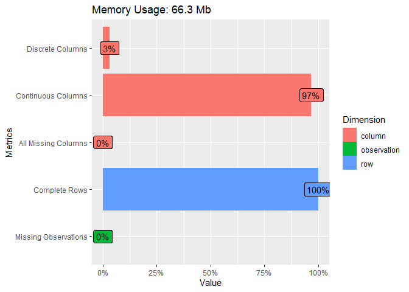

```r
plot_intro(bank_customers)
```

Sample

```r
table = flextable(bank_customers[1:5,],col_keys = names(bank_customers),
           cwidth = 0.75, cheight = 1, theme_fun = theme_tron_legacy)
# Add color to text and the body of the table
table <- color(table,color = "black", part = "body")
table <- bg(table,bg = "white")
table
```

| Time | V1 | V2 | V3 | V4 | V5 | V6 | V7 | V8 | V9 | V10 | V11 | V12 | V13 | V14 | V15 | V16 | V17 | V18 | V19 | V20 | V21 | V22 | V23 | V24 | V25 | V26 | V27 | V28 | Amount | … |
| --- | --- | --- | --- | --- | --- | --- | --- | --- | --- | --- | --- | --- | --- | --- | --- | --- | --- | --- | --- | --- | --- | --- | --- | --- | --- | --- | --- | --- | --- | --- |
| 0 | -1.3598071 | -0.07278117 | 2.5363467 | 1.3781552 | -0.33832077 | 0.46238778 | 0.23959855 | 0.09869790 | 0.3637870 | 0.09079417 | -0.5515995 | -0.61780086 | -0.9913898 | -0.3111694 | 1.4681770 | -0.4704005 | 0.2079712 | 0.02579058 | 0.4039930 | 0.25141210 | -0.018306778 | 0.277837576 | -0.1104739 | 0.06692807 | 0.1285394 | -0.1891148 | 0.133558377 | -0.02105305 | 149.62 | … |
| 0 | 1.1918571 | 0.26615071 | 0.1664801 | 0.4481541 | 0.06001765 | -0.08236081 | -0.07880298 | 0.08510165 | -0.2554251 | -0.16697441 | 1.6127267 | 1.06523531 | 0.4890950 | -0.1437723 | 0.6355581 | 0.4639170 | -0.1148047 | -0.18336127 | -0.1457830 | -0.06908314 | -0.225775248 | -0.638671953 | 0.1012880 | -0.33984648 | 0.1671704 | 0.1258945 | -0.008983099 | 0.01472417 | 2.69 | … |
| 1 | -1.3583541 | -1.34016307 | 1.7732093 | 0.3797796 | -0.50319813 | 1.80049938 | 0.79146096 | 0.24767579 | -1.5146543 | 0.20764287 | 0.6245015 | 0.06608369 | 0.7172927 | -0.1659459 | 2.3458649 | -2.8900832 | 1.1099694 | -0.12135931 | -2.2618571 | 0.52497973 | 0.247998153 | 0.771679402 | 0.9094123 | -0.68928096 | -0.3276418 | -0.1390966 | -0.055352794 | -0.05975184 | 378.66 | … |
| 1 | -0.9662717 | -0.18522601 | 1.7929933 | -0.8632913 | -0.01030888 | 1.24720317 | 0.23760894 | 0.37743587 | -1.3870241 | -0.05495192 | -0.2264873 | 0.17822823 | 0.5077569 | -0.2879237 | -0.6314181 | -1.0596472 | -0.6840928 | 1.96577500 | -1.2326220 | -0.20803778 | -0.108300452 | 0.005273597 | -0.1903205 | -1.17557533 | 0.6473760 | -0.2219288 | 0.062722849 | 0.06145763 | 123.50 | … |
| 2 | -1.1582331 | 0.87773675 | 1.5487178 | 0.4030339 | -0.40719338 | 0.09592146 | 0.59294075 | -0.27053268 | 0.8177393 | 0.75307443 | -0.8228429 | 0.53819555 | 1.3458516 | -1.1196698 | 0.1751211 | -0.4514492 | -0.2370332 | -0.03819479 | 0.8034869 | 0.40854236 | -0.009430697 | 0.798278495 | -0.1374581 | 0.14126698 | -0.2060096 | 0.5022922 | 0.219422230 | 0.21515315 | 69.99 | … |